# Prac_Lab_1

## Framing the Problem

The goal of this report is to develop a univariate predictive model for median house value using basic demographic and housing-related features. Specifically, we will explore the relationship between median house value and each of the following independent variables: median income, population, number of households

```python
import pandas as pd
import seaborn as sns
import matplotlib.pyplot as plt
from sklearn.linear_model import LinearRegression
from sklearn.metrics import mean_squared_error, r2_score, mean_absolute_error
import numpy as np
```

## Getting the Data

We will be using the [California Housing Prices Dataset on Kaggle](https://www.kaggle.com/datasets/camnugent/california-housing-prices) , which contains lots of information from the 1990 California census. This data includes features like median income, population, number of households, and median house value for different districts in California.

First we must load the data:

```python
# Load the data we downloaded
df = pd.read_csv('housing.csv')

# Display the first few rows to check if it is working correctly

df.head()
```

|  | longitude | latitude | housing_median_age | total_rooms | total_bedrooms | population | households | median_income | median_house_value | ocean_proximity |
| --- | --- | --- | --- | --- | --- | --- | --- | --- | --- | --- |
| 0 | -122.23 | 37.88 | 41.0 | 880.0 | 129.0 | 322.0 | 126.0 | 8.3252 | 452600.0 | NEAR BAY |
| 1 | -122.22 | 37.86 | 21.0 | 7099.0 | 1106.0 | 2401.0 | 1138.0 | 8.3014 | 358500.0 | NEAR BAY |
| 2 | -122.24 | 37.85 | 52.0 | 1467.0 | 190.0 | 496.0 | 177.0 | 7.2574 | 352100.0 | NEAR BAY |
| 3 | -122.25 | 37.85 | 52.0 | 1274.0 | 235.0 | 558.0 | 219.0 | 5.6431 | 341300.0 | NEAR BAY |
| 4 | -122.25 | 37.85 | 52.0 | 1627.0 | 280.0 | 565.0 | 259.0 | 3.8462 | 342200.0 | NEAR BAY |

## Exploratory Data Analysis (EDA)

First, let us explore the dataset so that we can further understand it:

```python
df.info()
```

```
<class 'pandas.core.frame.DataFrame'>
RangeIndex: 20640 entries, 0 to 20639
Data columns (total 10 columns):
 #   Column              Non-Null Count  Dtype
---  ------              --------------  -----
 0   longitude           20640 non-null  float64
 1   latitude            20640 non-null  float64
 2   housing_median_age  20640 non-null  float64
 3   total_rooms         20640 non-null  float64
 4   total_bedrooms      20433 non-null  float64
 5   population          20640 non-null  float64
 6   households          20640 non-null  float64
 7   median_income       20640 non-null  float64
 8   median_house_value  20640 non-null  float64
 9   ocean_proximity     20640 non-null  object
dtypes: float64(9), object(1)
memory usage: 1.6+ MB
```

```python
df.describe()
```

|  | longitude | latitude | housing_median_age | total_rooms | total_bedrooms | population | households | median_income | median_house_value |
| --- | --- | --- | --- | --- | --- | --- | --- | --- | --- |
| count | 20640.000000 | 20640.000000 | 20640.000000 | 20640.000000 | 20433.000000 | 20640.000000 | 20640.000000 | 20640.000000 | 20640.000000 |
| mean | -119.569704 | 35.631861 | 28.639486 | 2635.763081 | 537.870553 | 1425.476744 | 499.539680 | 3.870671 | 206855.816909 |
| std | 2.003532 | 2.135952 | 12.585558 | 2181.615252 | 421.385070 | 1132.462122 | 382.329753 | 1.899822 | 115395.615874 |
| min | -124.350000 | 32.540000 | 1.000000 | 2.000000 | 1.000000 | 3.000000 | 1.000000 | 0.499900 | 14999.000000 |
| 25% | -121.800000 | 33.930000 | 18.000000 | 1447.750000 | 296.000000 | 787.000000 | 280.000000 | 2.563400 | 119600.000000 |
| 50% | -118.490000 | 34.260000 | 29.000000 | 2127.000000 | 435.000000 | 1166.000000 | 409.000000 | 3.534800 | 179700.000000 |
| 75% | -118.010000 | 37.710000 | 37.000000 | 3148.000000 | 647.000000 | 1725.000000 | 605.000000 | 4.743250 | 264725.000000 |
| max | -114.310000 | 41.950000 | 52.000000 | 39320.000000 | 6445.000000 | 35682.000000 | 6082.000000 | 15.000100 | 500001.000000 |

## Visualize the Relationships

In order to understand this data fully lets go through some plots with three independent variables and the dependent variable median house value.

**Median Income vs. Median House Value**

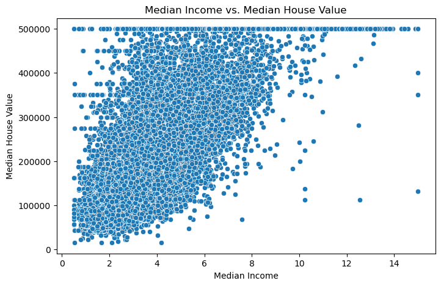

```python
plt.figure(figsize=(8, 5))
sns.scatterplot(x='median_income', y='median_house_value', data=df)
plt.title('Median Income vs. Median House Value')
plt.xlabel('Median Income')
plt.ylabel('Median House Value')
plt.show()
```

**Interpretation:** You can see a clear positive linear relationship between these two variables suggesting that Median Income will be a fantastic predictor, especially because we are running a linear regression model.

**Population vs. Median House Value**

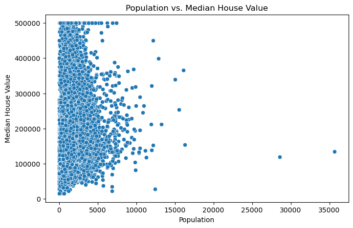

```python
plt.figure(figsize=(8, 5))
sns.scatterplot(x='population', y='median_house_value', data=df)
plt.title('Population vs. Median House Value')
plt.xlabel('Population')
plt.ylabel('Median House Value')
plt.show()
```

**Interpretation:** There is clearly a weak linear relationship here, if any at all, the points do not seem to follow a trend based on the population at all. This can mean that population is most likely not a good indicator of house value.

**Number of Households vs. Median House Value**

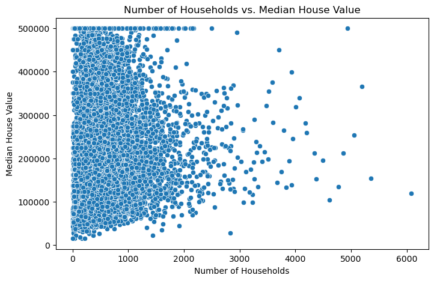

```python
plt.figure(figsize=(8, 5))
sns.scatterplot(x='households', y='median_house_value', data=df)
plt.title('Number of Households vs. Median House Value')
plt.xlabel('Number of Households')
plt.ylabel('Median House Value')
plt.show()
```

**Interpretation:** Here we can see that there is a slight positive linear trend between the two variables starting at the very bottom of the plot. However, the dispersion of points beyond that is much too high to consider this a strong relationship. This is another factor that is likely to be a weak predictor of house value.

### Variable Descriptions:

**Median House Value**

- This is simply a variable that represents median price of houses within a certain area
- This is the target variable in our regression model
- Has an approximate range of 15000 to 500001, this is actually very bad for the data selection because any value above this ceiling is reported as the max of 500001, this is going to skew the results of our regression

**Median Income**

- Represents Median income (tens of thousands of dollars)
- Ranges from 0 to 15 inclusive
- So far this variables has shown the strongest positive linear relationship with the median house value

**Population**

- Indicates the population of people in the certain area
- Very high fluctuation in the range depending on location
- So far there is no clear correlation between population and median house value

**Number of Households**

- Represents the number of houses in the area
- There is signifcant variation in the range of the variable
- Indicates a very weak positive linear trend but is too weak to indicate anything signifcant

## Begin the Linear Regression

**Code for Median Income vs Median House Value**

```python
# Collect applicable data variables
X_income = df[['median_income']]
y = df['median_house_value']

# Create and fit the model
model_income = LinearRegression()
model_income.fit(X_income, y)

# Predict
y_pred_income = model_income.predict(X_income)

# Evaluation
slope_income = model_income.coef_[0]
intercept_income = model_income.intercept_
mse_income = mean_squared_error(y, y_pred_income)
mae_income = mean_absolute_error(y, y_pred_income)
r2_income = r2_score(y, y_pred_income)
```

**Code for Population vs Median House Value**

```python
# Collect applicable variables
X_pop = df[['population']]
y = df['median_house_value']

# Create and fit the model
model_pop = LinearRegression()
model_pop.fit(X_pop, y)

# Predict
y_pred_pop = model_pop.predict(X_pop)

# Evaluation
slope_pop = model_pop.coef_[0]
intercept_pop = model_pop.intercept_
mse_pop = mean_squared_error(y, y_pred_pop)
mae_pop = mean_absolute_error(y, y_pred_pop)
r2_pop = r2_score(y, y_pred_pop)
```

**Code for Number of Households vs Median House Value**

```python
# Collect applicable variables
X_households = df[['households']]
y = df['median_house_value']

# Create and fit the model
model_households = LinearRegression()
model_households.fit(X_households, y)

# Predict
y_pred_households = model_households.predict(X_households)

# Evaluation
slope_households = model_households.coef_[0]
intercept_households = model_households.intercept_
mse_households = mean_squared_error(y, y_pred_households)
mae_households = mean_absolute_error(y, y_pred_households)
r2_households = r2_score(y, y_pred_households)
```

### Summarize the Results

```python
# Create a summary table
comparison = pd.DataFrame({
    'Feature': ['Median Income', 'Population', 'Households'],
    'Intercept': [intercept_income, intercept_pop, intercept_households],
    'Slope': [slope_income, slope_pop, slope_households],
    'Mean Squared Error': [mse_income, mse_pop, mse_households],
    'Mean Absolute Error': [mae_income, mae_pop, mae_households]
})

comparison.round(2)
```

|  | Feature | Intercept | Slope | Mean Squared Error | Mean Absolute Error |
| --- | --- | --- | --- | --- | --- |
| 0 | Median Income | 45085.58 | 41793.85 | 7.011312e+09 | 62625.93 |
| 1 | Population | 210436.26 | -2.51 | 1.330741e+10 | 91153.82 |
| 2 | Households | 196928.58 | 19.87 | 1.325778e+10 | 90802.74 |

## New Visualization of Relationships

**Median Income vs. Median House Value**

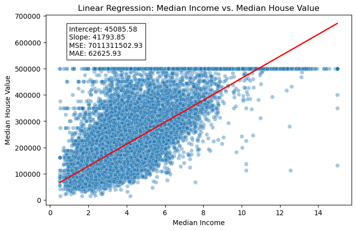

```python
plt.figure(figsize=(8, 5))
sns.scatterplot(x='median_income', y='median_house_value', data=df, alpha=0.4)
plt.plot(df['median_income'], y_pred_income, color='red')
plt.title('Linear Regression: Median Income vs. Median House Value')
plt.xlabel('Median Income')
plt.ylabel('Median House Value')

# Add annotation box
plt.text(1, 550000,
         f"Intercept: {intercept_income:.2f}\n"
         f"Slope: {slope_income:.2f}\n"
         f"MSE: {mse_income:.2f}\n"
         f"MAE: {mae_income:.2f}",
         bbox=dict(facecolor='white', alpha=0.8))
plt.show()
```

**Population vs. Median House Value**

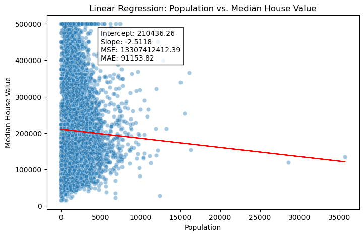

```python
plt.figure(figsize=(8, 5))
sns.scatterplot(x='population', y='median_house_value', data=df, alpha=0.4)
plt.plot(df['population'], y_pred_pop, color='red')
plt.title('Linear Regression: Population vs. Median House Value')
plt.xlabel('Population')
plt.ylabel('Median House Value')

plt.text(5000, 400000,
         f"Intercept: {intercept_pop:.2f}\n"
         f"Slope: {slope_pop:.4f}\n"
         f"MSE: {mse_pop:.2f}\n"
         f"MAE: {mae_pop:.2f}",
         bbox=dict(facecolor='white', alpha=0.8))
plt.show()
```

**Households vs. Median House Value**

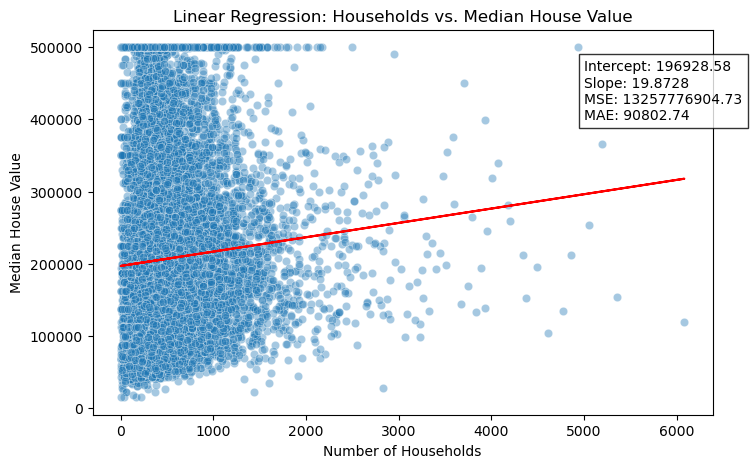

```python
plt.figure(figsize=(8, 5))
sns.scatterplot(x='households', y='median_house_value', data=df, alpha=0.4)
plt.plot(df['households'], y_pred_households, color='red')
plt.title('Linear Regression: Households vs. Median House Value')
plt.xlabel('Number of Households')
plt.ylabel('Median House Value')

plt.text(5000, 400000,
         f"Intercept: {intercept_households:.2f}\n"
         f"Slope: {slope_households:.4f}\n"
         f"MSE: {mse_households:.2f}\n"
         f"MAE: {mae_households:.2f}",
         bbox=dict(facecolor='white', alpha=0.8))
plt.show()
```

## Summarize the Results

In this Lab we ran linear regressions on three different variates to determine their relationship with the dependent variate Median House Value.

Below I have displayed a table that sums up the results in a concise manner:

[output not shown]

We demonstrated the following:

**Key Insights:**

This biggest issue with this lab was actually the data itself. The Median House Value having a ceiling was a major issue in terms of data selection. This means that any data above the ceiling (500001) will be written as 500001, this will heavily skew the data because in this case there are many points that are at this ceiling which will underestimate high valued properties.

The second scatter plots can confirm that the only positive linear trend that had any accuracy was the Median Income variate. This result is inline with the original scatterplot as well as all the interpretation we wrote while discussing the previous scatterplot.